# Quynh’s Media Consumption in 2024

Quynh Phung

I’ve consumed a lot of media in the last twelve months, and this project attempts to organize, summarize, and visualize the data I tracked in 2024. I only track movies, albums, and books, but that represents the vast majority of my media consumption. I rate each piece of media out of 20 because it provides the perfect balance in which every integer represents a meaningful difference in quality.

# Albums

In 2024, I listened to 85 studio albums for the first time, compared to 50 in 2023, the first year I started tracking albums. Of those 85 albums, 31 were released in 2024. This totaled over 61 hours of new music, with the longest album, Taylor Swift’s *The Tortured Poet’s Department* clocking in at over 2 hours long, and the shortest, Martin Luke Brown’s *damn, look at the view!* coming in at less than 25 minutes. The average album length was 43.44 minutes. This table contains all the data I track for the albums I listen to. The table is sorted by default by my personal ranking of all 85 albums, but you can sort and filter by any of the columns, search the table, or change the number of entries displayed on each page.

| rank | date.listened | title | artist | date.released | num.tracks | length | genre | recommender | rating |
| --- | --- | --- | --- | --- | --- | --- | --- | --- | --- |
| 1 | 2024-12-28 | imaginal disk | magdalena bay | 2024 | 15 | 53 | synth pop | ashwin | 20 |
| 2 | 2024-06-18 | brat | charli xcx | 2024 | 18 | 50 | electropop | quynh | 20 |
| 3 | 2024-09-01 | surrender | maggie rogers | 2022 | 12 | 46 | indie pop | quynh | 20 |
| 4 | 2024-05-23 | clancy | twenty one pilots | 2024 | 13 | 47 | alt rock | quynh | 19 |
| 5 | 2024-12-03 | trip into the body | johan timman | 1981 | 11 | 50 | electronic funk | hayley | 19 |
| 6 | 2024-03-20 | head hunters | herbie hancock | 1973 | 4 | 41 | jazz funk | quynh | 19 |
| 7 | 2024-03-22 | casiopea | casiopea | 1979 | 8 | 36 | jazz fusion | ben | 19 |
| 8 | 2024-06-27 | the rubaiyat of dorothy ashby | dorothy ashby | 1970 | 10 | 39 | jazz fusion | quynh | 19 |
| 9 | 2024-12-09 | long season | fishmans | 1996 | 1 | 35 | japanese rock | jade | 18 |
| 10 | 2024-09-09 | muna | muna | 2022 | 11 | 39 | indie pop | quynh | 18 |

[output cut: 75 more lines]

The distribution of my ratings looks like:

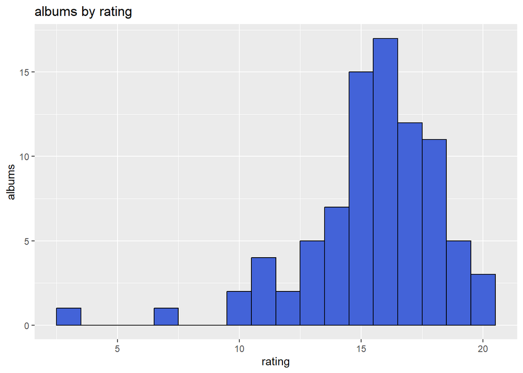

This looks like a skewed normal distribution, with an average rating of 15.47 and a standard deviation of 2.82. Presumably, the distribution of ratings for all the albums in the world would not be skewed, but my personal ratings fall mostly in the 15-18 range because I don’t often challenge myself to listen to music I might not like.

We can also look at the number of albums I listened to in each month:

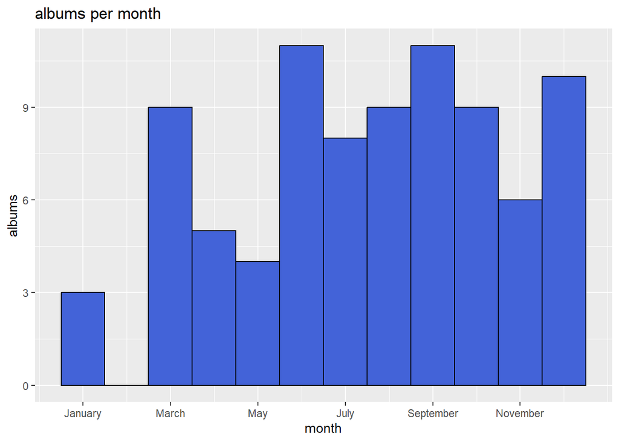

Of the three types of media I track, music is the most resilient to outside factors in my life, because I can and do listen to music while performing other activities. Even from January through April when I was finishing grad school, I listened to new albums at a relatively consistent rate, other than March when I entered my first jazz funk fusion era, and even after graduating in May, the rate never rose above 11 albums in a month.

One further data point we can examine is the person who recommended me each album.

| ranking | recommender | num.albums | avg.rating |
| --- | --- | --- | --- |
| 1 | ashwin | 1 | 20 |
| 2 | hayley | 1 | 19 |
| 3 | sidd | 1 | 18 |
| 4 | tru | 1 | 18 |
| 5 | jade | 2 | 17.5 |
| 6 | ben | 2 | 16.5 |
| 7 | patrick | 1 | 16 |
| 8 | vishnu | 7 | 15.43 |
| 9 | jane | 3 | 15.33 |
| 10 | quynh | 62 | 15.31 |

[output cut: 2 more lines]

and we can plot it against rating on our histogram:

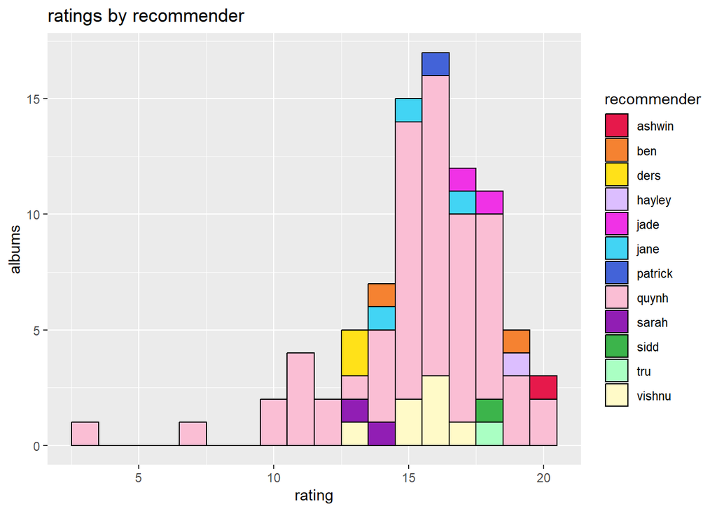

We can also look at each album’s release year:

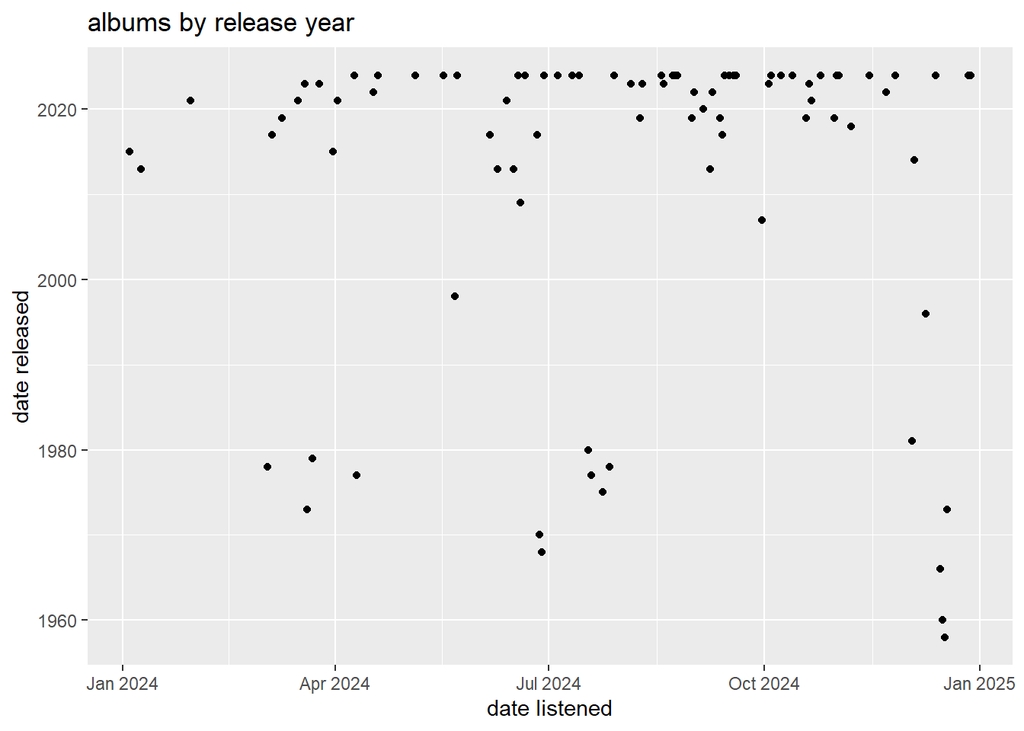

which shows that I mostly stick to music post-2015, with three main dips, one in each of my jazz funk fusion eras, in March and April, late June to July, and the first half of December.

We can also examine whether an album’s length has any bearing on my rating,

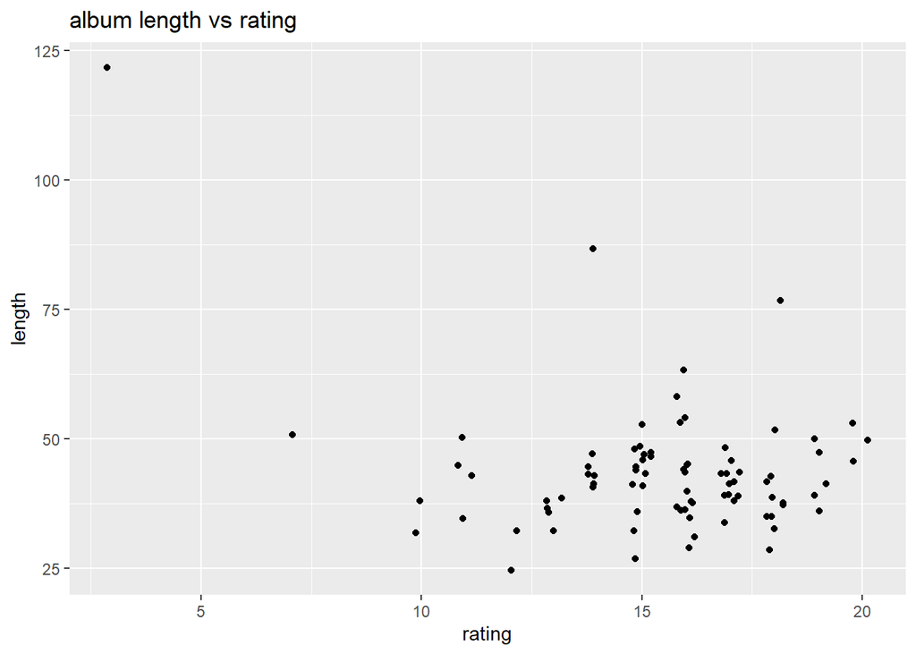

which reveals a slight trend: in general I tend to enjoy shorter albums.

We can also examine the artists I listened to multiple albums from:

| artist | num.albums | avg.rating |
| --- | --- | --- |
| dorothy ashby | 2 | 17.5 |
| twenty one pilots | 3 | 17.33 |
| maggie rogers | 4 | 17 |
| paramore | 4 | 16.75 |
| muna | 3 | 16.67 |
| cory wong | 4 | 16.5 |
| the aces | 3 | 16.33 |
| the japanese house | 2 | 15 |
| patti smith | 2 | 14.5 |
| holy holy | 4 | 13 |

[output cut: 2 more lines]

which pretty much shows all my favorite artists that I discovered in 2024.

The other data point that would be interesting to draw conclusions from is the genre of each album; however, that is much more complicated to track as the lines between genres are blurry, and I assigned genre names rather arbitrarily. This data point would require a more robust treatment than I am prepared to spend time on at this point. This applies to book and movie genres as well.

# Movies

In 2024, I watched 120 movies for the first time. This is the first year I’ve tracked my movies watched. This totaled over 215 hours of movies, with the longest movie, *Satantango*, clocking in at over 7 hours, and the shortest short film, “Just a Minute,” clocking in at 3 minutes. The average movie length was 107.69 minutes. This table contains all the data I track for movies:

| rank | date.watched | title | director | date.released | length | rating | letterboxd |
| --- | --- | --- | --- | --- | --- | --- | --- |
| 1 | 2024-04-10 | portrait of a lady on fire | céline sciamma | 2019 | 121 | 20 | 17.6 |
| 2 | 2024-09-07 | 10 things I hate about you | gil junger | 1999 | 97 | 20 | 16 |
| 3 | 2024-08-30 | but I'm a cheerleader | jamie babbit | 1999 | 85 | 20 | 16 |
| 4 | 2024-08-19 | women talking | sarah polley | 2022 | 104 | 20 | 15.2 |
| 5 | 2024-06-28 | lisa frankenstein | zelda williams | 2024 | 102 | 19 | 14 |
| 6 | 2024-06-29 | plum blossom (revisited) mini-doc | will stockwell, brian christ | 2023 | 5 | 19 | 19.6 |
| 7 | 2024-11-23 | bottoms | emma seligman | 2023 | 91 | 19 | 15.2 |
| 8 | 2024-08-22 | shiva baby | emma seligman | 2020 | 78 | 19 | 15.2 |
| 9 | 2024-09-22 | frances ha | noah baumbach | 2012 | 86 | 19 | 16 |
| 10 | 2024-05-31 | love lies bleeding | rose glass | 2024 | 104 | 19 | 14.4 |

[output cut: 110 more lines]

The distribution of ratings for movies looks like:

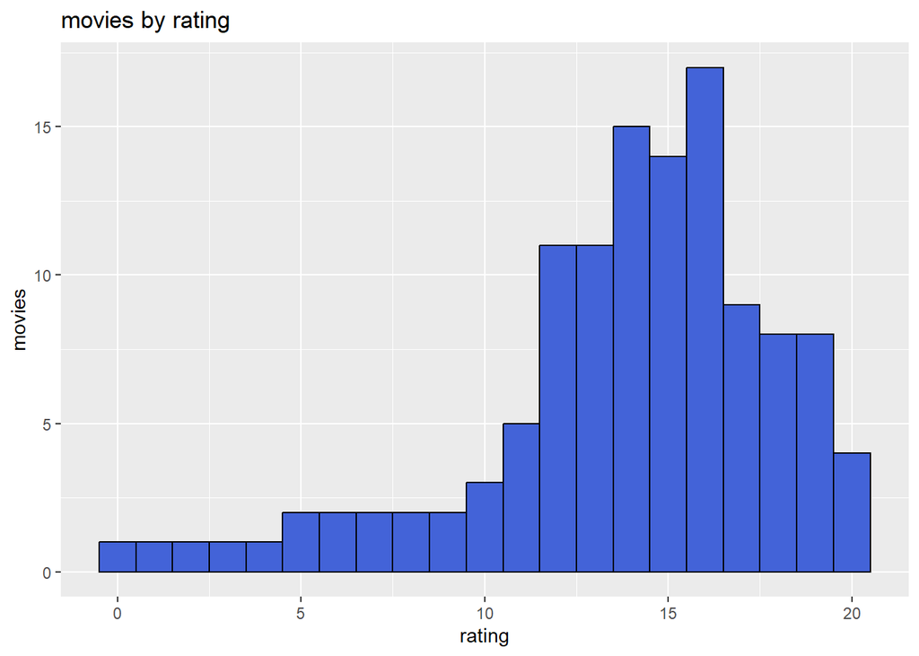

Which again, looks like a skewed normal distribution, with an average rating of 13.84 and a standard deviation of 4.12. The mean is lower and the standard deviation is higher than my distribution for albums, probably because I have a higher tolerance to watch mid-to-bad movies and because of the larger sample size.

Looking at the number of movies I watched in each month throughout the year:

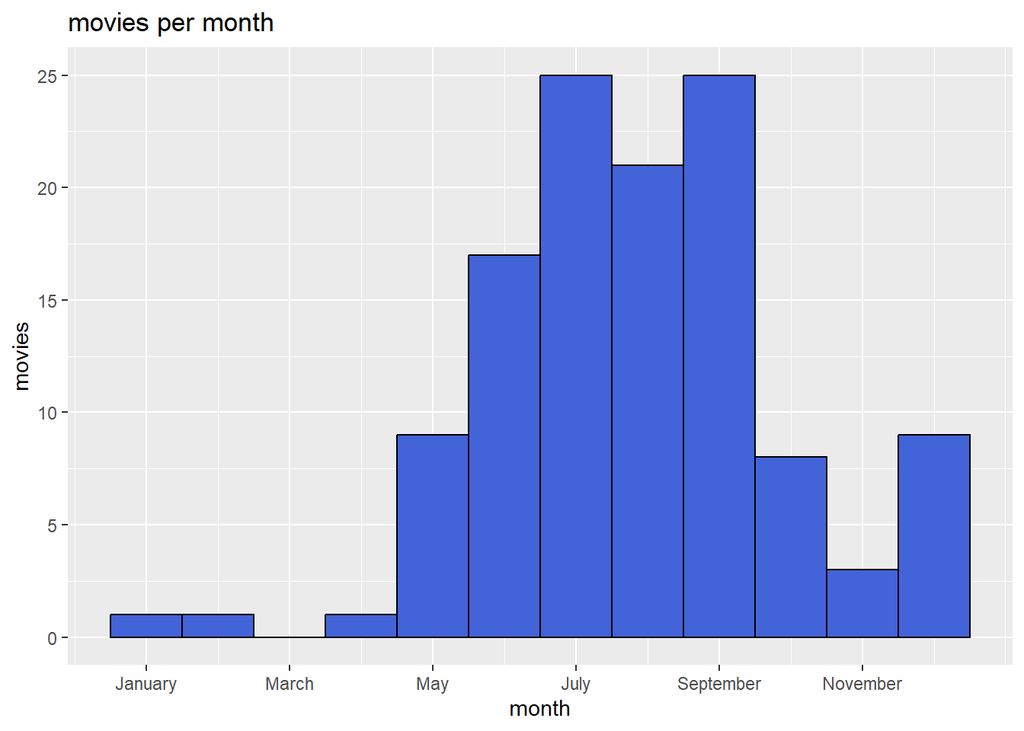

My movie watching habits are much less resilient than my music listening, as evidenced by the dearth of movies watched while I was finishing grad school, the big jump to 15-25 movies per month over the summer, at some points close to a movie every day, and the sharp drop off in October when I moved to Ohio.

The graph of release years for each movie reveals less info than it did for albums:

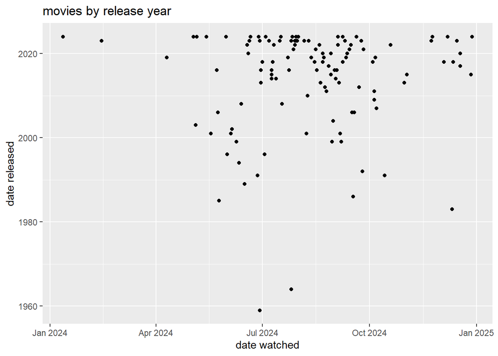

And similarly for the movie length,

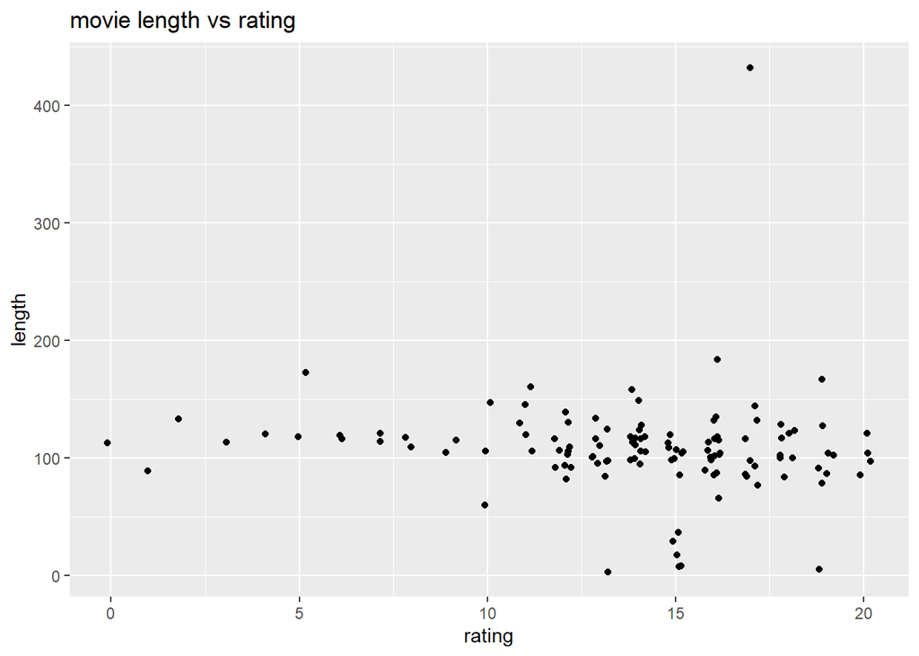

An interesting stat to calculate is the difference between my rating and Letterboxd’s rating, which is summarized in this table:

| title | director | rating | letterboxd | rating.difference |
| --- | --- | --- | --- | --- |
| daddio | christy hall | 18 | 12.8 | 5.2 |
| lisa frankenstein | zelda williams | 19 | 14 | 5 |
| am I ok? | tig notaro, stephano allynne | 17 | 12 | 5 |
| assassin's creed | justin kurzel | 13 | 8 | 5 |
| women talking | sarah polley | 20 | 15.2 | 4.8 |
| reality | tina satter | 18 | 13.2 | 4.8 |
| love lies bleeding | rose glass | 19 | 14.4 | 4.6 |
| anyone but you | will gluck | 16 | 11.6 | 4.4 |
| 10 things I hate about you | gil junger | 20 | 16 | 4 |
| but I'm a cheerleader | jamie babbit | 20 | 16 | 4 |

[output cut: 110 more lines]

The most positive rating differences were for movies I enjoyed that were mid to most of the Letterboxd audience, including two Dakota Johnson movies, *Daddio* and *Am I OK?*. The most negative differences were mostly movies that I greatly disliked, including bad movies like *Eat Pray Love*, *Not Another Teen Movie*, and *Mean Girls*, and problematic movies like *Cloud Atlas*, *Babyteeth*, and *Promising Young Woman*.

We can also look at all the directors I watched multiple movies from:

| director | num.movies | avg.rating |
| --- | --- | --- |
| emma seligman | 3 | 17.67 |
| céline sciamma | 3 | 17 |
| mike newell | 2 | 15.5 |
| ti west | 3 | 14.33 |
| jon m. chu | 2 | 11 |
| todd haynes | 2 | 11 |
| robert schwentke | 2 | 5 |

This list is topped by two of my favorite directors, Emma Seligman and Celine Sciamma, who have three movies including one short film each. They are joined in the 3 movies group by Ti West due to his *X*-*Pearl*-*MaXXXine* trilogy, of which *Pearl* is doing most of the heavy lifting for his rating. The dubious distinction of last place on this list goes to Robert Schwentke, who directed *Insurgent* and *Allegiant* from the *Divergent* film trilogy.

# Books

In 2024, I read 64 books for the first time, compared to 6 in 2023 and 25 in 2022, the first year I started tracking books. This totaled 24475 pages read, with the longest two books, Samantha Shannon’s *The Priory of the Orange Tree* and *A Day of Fallen Night* clocking in at 845 and 868 pages each, and the shortest being John Steinbeck’s novella “The Pearl” at 96 pages. The average book length was 382.42 pages. This table contains the rankings and data for all 64 books:

| rank | date.read | title | author | date.published | num.pages | rating | goodreads |
| --- | --- | --- | --- | --- | --- | --- | --- |
| 1 | 2024-09-06 | 6 times we almost kissed [and one time we did] | tess sharpe | 2023 | 384 | 20 | 16.72 |
| 2 | 2024-09-05 | imogen, obviously | becky albertalli | 2023 | 432 | 20 | 16.88 |
| 3 | 2024-12-25 | kiss her once for me | alison cochrun | 2022 | 368 | 20 | 15.36 |
| 4 | 2024-08-16 | the priory of the orange tree | samantha shannon | 2019 | 845 | 19 | 16.72 |
| 5 | 2024-08-04 | the bell jar | sylvia plath | 1963 | 294 | 19 | 16.24 |
| 6 | 2024-05-17 | zoroastrians | mary boyce | 1979 | 284 | 19 | 16.12 |
| 7 | 2024-10-21 | the managed heart | arlie russell hochschild | 1983 | 330 | 19 | 15.96 |
| 8 | 2024-07-10 | the adventures of amina al-sirafi | shannon chakraborty | 2023 | 483 | 19 | 17.08 |
| 9 | 2024-12-29 | the grace year | kim liggett | 2019 | 416 | 18 | 16.6 |
| 10 | 2024-08-29 | flight | lynn steger strong | 2022 | 240 | 18 | 13.68 |

[output cut: 54 more lines]

The distribution of ratings for the books looks like:

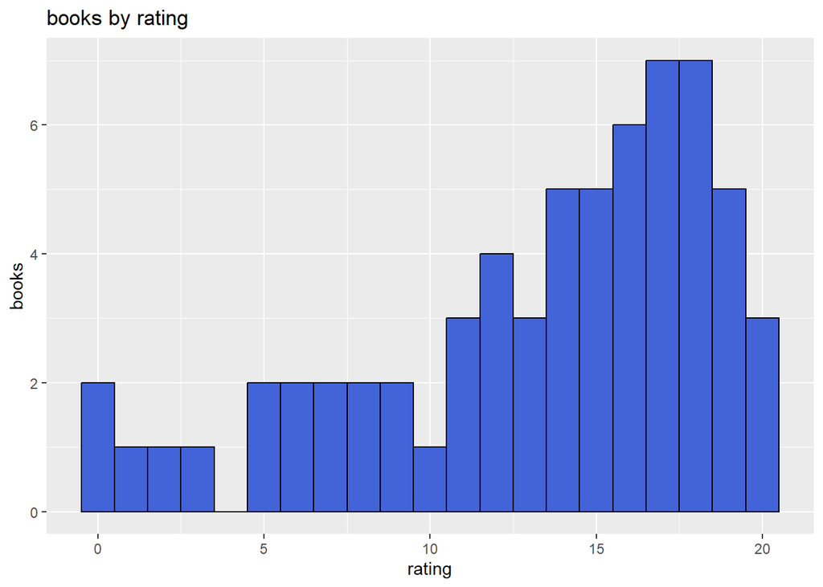

which again looks like a skewed normal distribution, with an average rating of 13.23 and a standard deviation of 5.34. The mean is even lower and the standard deviation higher than the distribution of my movie ratings, but the mode for books is the highest of all three media types, 17 and 18. I believe this is because books are the most involved of the three media types, so I am less likely to have ambivalent feelings and more likely to feel strongly for or against the book because I spent so much time on it. I am also much more willing to read really bad books than listen to bad albums or watch bad movies.

Looking at the number of books I read in each month:

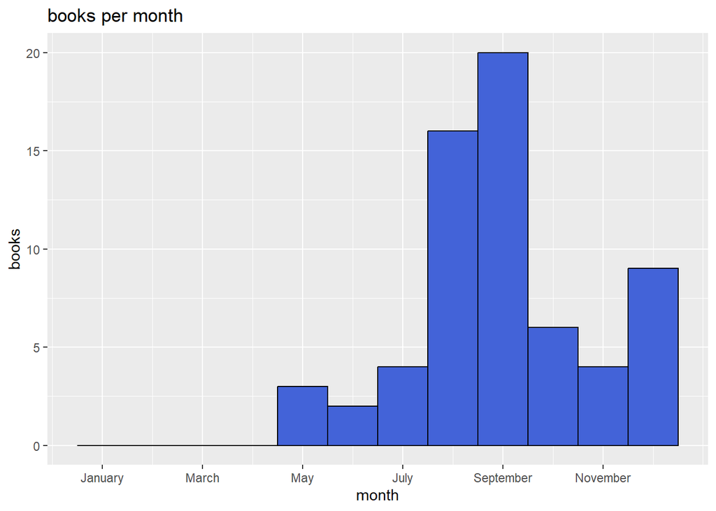

Books are the least resilient type of media to outside factors. I didn’t finish a single book the entire time I was finishing grad school, working on Mary Boyce’s *Zoroastrians* for the entire four months. The rate of book reading jumped significantly to finishing a book about every other day during my months in Mahomet in August and September, and than came straight back down in October and November when I moved to Huron, jumping up again when I had time to read over the holidays in December.

The publication date seems to have little correlation with my enjoyment of a book:

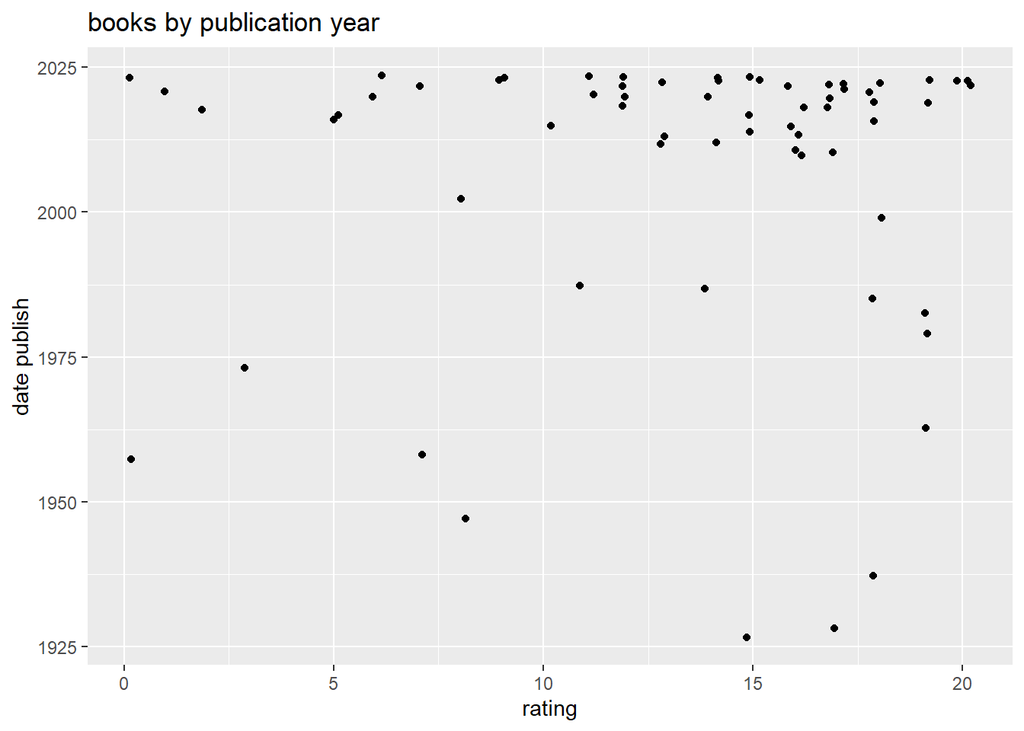

and same with the length of a book:

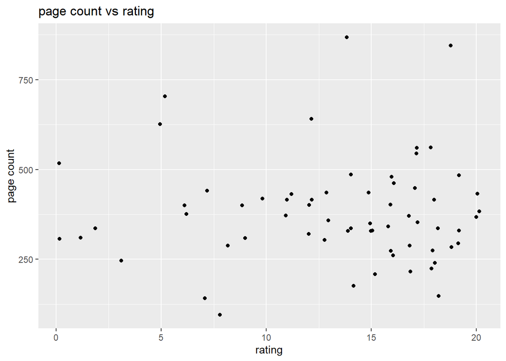

Similarly to movies, we can calculate the difference between my rating and Goodreads’ rating:

| title | author | rating | goodreads | rating.difference |
| --- | --- | --- | --- | --- |
| kiss her once for me | alison cochrun | 20 | 15.36 | 4.64 |
| flight | lynn steger strong | 18 | 13.68 | 4.32 |
| 6 times we almost kissed [and one time we did] | tess sharpe | 20 | 16.72 | 3.28 |
| some girls do | jennifer dugan | 18 | 14.8 | 3.2 |
| imogen, obviously | becky albertalli | 20 | 16.88 | 3.12 |
| the managed heart | arlie russell hochschild | 19 | 15.96 | 3.04 |
| zoroastrians | mary boyce | 19 | 16.12 | 2.88 |
| the bell jar | sylvia plath | 19 | 16.24 | 2.76 |
| women talking | miriam toews | 17 | 14.48 | 2.52 |
| the priory of the orange tree | samantha shannon | 19 | 16.72 | 2.28 |

[output cut: 54 more lines]

Again, the most positive differences were from books I loved, including several sapphic romances like *Kiss Her Once for Me*, *6 Times We Almost Kissed [And One Time We Did]*, *Some Girls Do*, and *Imogen, Obviously*. On the other hand, the most negative differences were books I really hated, bottoming out with my two least favorite books of all time, *On the Road* and *Fourth Wing*.

Examining again the authors I read multiple books from:

| author | num.books | avg.rating |
| --- | --- | --- |
| samantha shannon | 2 | 16.5 |
| victoria schwab | 2 | 16 |
| r.f. kuang | 2 | 15.5 |
| jennifer dugan | 2 | 15 |
| leigh bardugo | 5 | 15 |
| emily m. danforth | 2 | 13 |
| sarah j. maas | 3 | 6.67 |

Leigh Bardugo comes in with the most books due to both her *Shadow and Bones* and *Six of Crows* series, while the first three books of *A Court of Thorns and Roses* puts Sarah J. Maas in second place in terms of number of books, although she is very much dead last in rating. Samantha Shannon’s *Priory* world is easily my favorite of the repeat authors, followed by Victoria Schwab’s *Villains* series.

# Combined

Aggregating all this data, we arrive at my definitive ranking of all 269 albums, movies, and books I consumed in 2024:

| rank | date.consumed | title | maker | date.released | type | rating |
| --- | --- | --- | --- | --- | --- | --- |
| 1 | 2024-04-10 | portrait of a lady on fire | céline sciamma | 2019 | movie | 20 |
| 2 | 2024-09-06 | 6 times we almost kissed [and one time we did] | tess sharpe | 2023 | book | 20 |
| 3 | 2024-09-05 | imogen, obviously | becky albertalli | 2023 | book | 20 |
| 4 | 2024-12-28 | imaginal disk | magdalena bay | 2024 | album | 20 |
| 5 | 2024-09-07 | 10 things I hate about you | gil junger | 1999 | movie | 20 |
| 6 | 2024-06-18 | brat | charli xcx | 2024 | album | 20 |
| 7 | 2024-12-25 | kiss her once for me | alison cochrun | 2022 | book | 20 |
| 8 | 2024-09-01 | surrender | maggie rogers | 2022 | album | 20 |
| 9 | 2024-08-30 | but I'm a cheerleader | jamie babbit | 1999 | movie | 20 |
| 10 | 2024-08-19 | women talking | sarah polley | 2022 | movie | 20 |

[output cut: 259 more lines]

The overall distribution of ratings is:

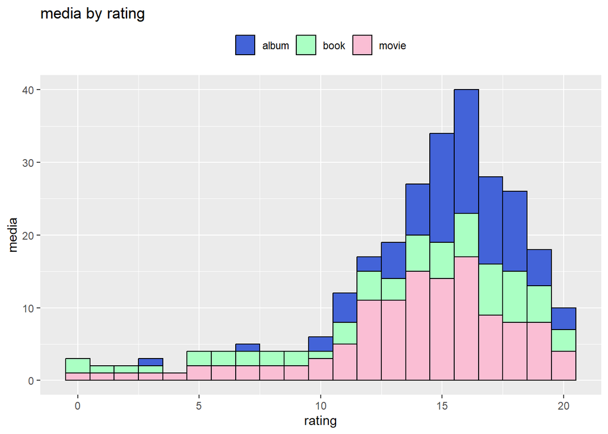

whose summary statistics are a mean of 14.21 and a standard deviation of 4.19.

The timeline by month:

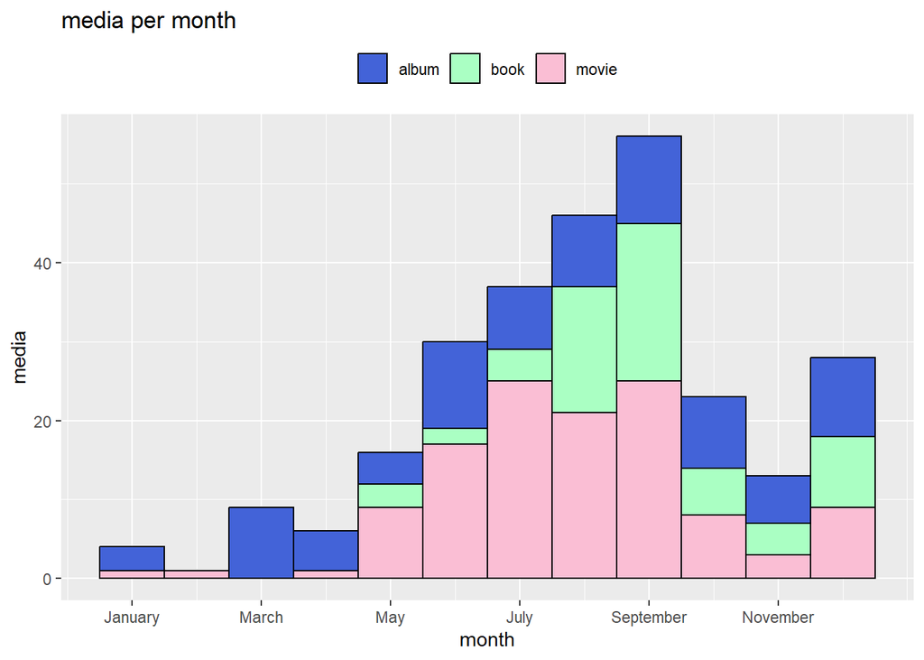

I only achieved the “triple double” (at least 10 of each media type in a month) once in September, but I was one album away in August and one book away in December (counting movie rewatches, which I didn’t include in this summary).

We can look at the relationship between release year and rating:

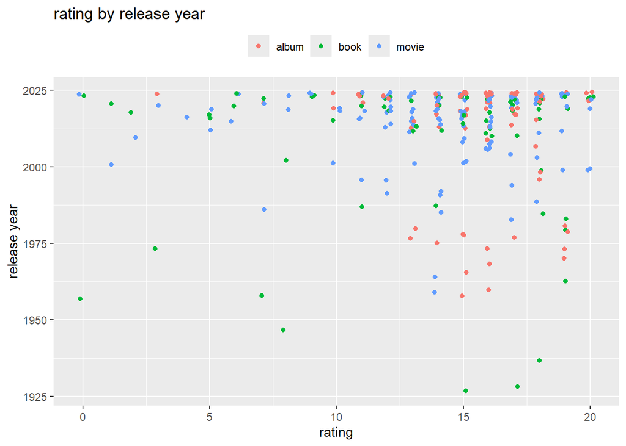

And like previously, examine the repeat makers:

| maker | num.media | avg.rating |
| --- | --- | --- |
| emma seligman | 3 | 17.67 |
| dorothy ashby | 2 | 17.5 |
| twenty one pilots | 3 | 17.33 |
| céline sciamma | 3 | 17 |
| maggie rogers | 4 | 17 |
| paramore | 4 | 16.75 |
| muna | 3 | 16.67 |
| cory wong | 4 | 16.5 |
| samantha shannon | 2 | 16.5 |
| the aces | 3 | 16.33 |

[output cut: 16 more lines]

The final piece of data is what one of my friends dubbed the “triple crown,” days on which I listened to a new album, finished a book, and watched a movie all on the same day. This occurred 13 times in 2024:

| date | album | movie | book |
| --- | --- | --- | --- |
| 2024-06-29 | don't forget me | gidget | a court of thorns and roses |
| 2024-07-29 | dot | hit man | in search of zarathustra |
| 2024-08-09 | when this plane goes down | eat pray love | on the road |
| 2024-08-10 | the secret to life | daddio | a visit from the goon squad |
| 2024-08-23 | short n' sweet | our friend | women talking |
| 2024-08-25 | egosystem | the raid | a court of mist and fury |
| 2024-08-31 | heard it in a past life | speak | siege and storm |
| 2024-09-01 | surrender | certain women | ruin and rising |
| 2024-09-05 | notes from the archive | survive and advance | she drives me crazy |
| 2024-09-14 | stuck at the playground | happening | the well of loneliness |

[output cut: 3 more lines]

This was a lot of fun, and I will definitely be doing this again for 2025. My goal for this year is 75 books, 100 albums, and 150 movies. Let me know if you have any ideas for further data visualizations or would like to see any particular stats. If you have any comments on any of the media I consumed in 2024, I’d also love to hear them. And finally, I am always taking recommendations for any movies, books, or albums you think I might like.